# Validate E-MTAB-7183 AMD Eye Hits

## Quality Control - Probe Filtering

### Step 1: Load SWAN-normalised objects.

```r
load("~/KoborLab/kobor_space/kendrix/macular_degeneration/data/AMD_MSet.swan.RData")
```

### Step 2: Sex probes removal.

Probes that target the sex chromosomes are removed as both males and females have unequal amount X chromosomes - with females having twice the amount of X chromosomes as compared to males. So they need to be removed so that the analysis is not skewed on the basis of this disproportionate natural difference in chromosomal number.

```r
data(IlluminaHumanMethylation450kmanifest)
data(Locations)

#Check probe count before removal.
dim(AMD_MSet.swan) #485512 probes.
```

```
## [1] 485512     44
```

```r
#Get sex probes information from manifest file.
sex_probes <- Locations[which(Locations$chr == "chrY" | Locations$chr == "chrX"), ] %>% as.data.frame()
dim(sex_probes) #19627 probes.
```

```
## [1] 19627     3
```

```r
#Check the number of sex probes in the beta matrix.
AMD_sex_probes <- AMD_MSet.swan[which(rownames(AMD_MSet.swan) %in% rownames(sex_probes)),]
dim(AMD_sex_probes) #10583 probes.
```

```
## [1] 10583    44
```

```r
#Remove sex probes from AMD beta matrix.
AMD_MSet.swan <- AMD_MSet.swan[!(rownames(AMD_MSet.swan)%in%rownames(sex_probes)),]
dim(AMD_MSet.swan) #474929 probes remaining after sex probes filtering.
```

```
## [1] 474929     44
```

### Step 3: Cross-reactive probes removal.

Porter et al. uses [Chen et al.’s annotation](https://www.ncbi.nlm.nih.gov/pmc/articles/PMC3592906) to remove cross-reactive and polymorphic probes, which is why I’m replicating this step here.

```r
#Load cross-reactive probes.
cross.react <- read.csv("~/KoborLab/kobor_space/kendrix/macular_degeneration/data/Non_specific_probes_450K.csv", header = TRUE, as.is = TRUE)
cross.react.probes <- as.character(cross.react$TargetID)

#Check the number of cross-reactive probes in the beta matrix.
AMD_cross.react_probes <- AMD_MSet.swan[which(rownames(AMD_MSet.swan) %in% cross.react.probes),]
dim(AMD_cross.react_probes) #28379 probes.
```

```
## [1] 28379    44
```

```r
#Remove cross-reactive probes from AMD beta matrix.
AMD_MSet.swan <- AMD_MSet.swan[!(rownames(AMD_MSet.swan) %in% cross.react.probes),]
dim(AMD_MSet.swan) #446550 probes remaining after sex probes filtering.
```

```
## [1] 446550     44
```

### Step 4: Detection p-value and beadcount.

```r
#Filter probes that have detection p-value thresholds of more than 0.01.
load("~/KoborLab/kobor_space/kendrix/macular_degeneration/data/AMD_detp_beadcount_QC.RData")

#Create a dummy matrix
bad_probes <- matrix(data = F, nrow = nrow(detp_minfi), ncol = ncol(detp_minfi),
                        dimnames = list(rownames(detp_minfi), colnames(detp_minfi))) %>% as.data.frame

#Designate TRUE to where beadcount < 3 and detection p-value > 0.01.
bad_probes[is.na(bead)] <- T
bad_probes[detp_minfi > 0.01] <- T

#Check for probes that are unsuccesfully measured in nth% of samples.
n_samples <- ncol(AMD_MSet.swan)
bad_probes_count <- rowSums(bad_probes)

#Check thresholds to determine number of probes to remove:
#Probes that are unsuccessfully measured in 1% of samples.
sum(bad_probes_count > 0.010*n_samples) #18814 probes.
```

```
## [1] 18814
```

```r
#Probes that are unsuccessfully measured in 2.5% of samples.
sum(bad_probes_count > 0.025*n_samples) #5050 probes.
```

```
## [1] 5050
```

```r
#Probes that are unsuccesfully measured in 5% of samples.
sum(bad_probes_count > 0.050*n_samples) #3318 probes.
```

```
## [1] 3318
```

```r
#Remove probes that are unsuccessfully measured in 5% of samples.
remove_probes <- data.frame(probe_ID = rownames(detp_minfi)) %>% mutate(bad_probes_count = bad_probes_count) %>% filter(bad_probes_count > 0.05*n_samples)
AMD_MSet.swan <- AMD_MSet.swan[!(rownames(AMD_MSet.swan) %in% remove_probes$probe_ID),]
dim(AMD_MSet.swan) #443768 probes remaining after detection p-value and beadcount probe filtering.
```

```
## [1] 443768     44
```

### Step 5: Probes associated with SNPs removal.

The function dropLociWithSnps allows to drop probes that contain either a SNP at the CpG interrogation or at the single nucleotide extension.

```r
#Convert MSet object to GenomicMethylSet object.
AMD_GenomicMSet.swan <- mapToGenome(AMD_MSet.swan)

AMD_GenomicMSet.swan.filt <- dropLociWithSnps(AMD_GenomicMSet.swan, maf = 0.05)
dim(AMD_GenomicMSet.swan.filt) #437486 probes remaining after probes associated with SNPs are dropped.
```

```
## [1] 437486     44
```

### Step 6: Post probe filtering PCA.

```r
#Load the probe filtered beta matrix.
betas.swan <- getBeta(AMD_GenomicMSet.swan.filt)

meta <- as.data.frame(pData(AMD_GenomicMSet.swan.filt))
PCA_full <- princomp(betas.swan) #You can't have NAs in your dataframe - make sure to either remove probes with a lot of NAs and/or have imputed values. Can run na.omit but depending on the stage of pre-processing, could result in a lot of probes to be removed and a very inaccurate PCA.
Loadings <- as.data.frame(unclass(PCA_full$loadings))
vars <- PCA_full$sdev^2
Importance <- vars/sum(vars)
adjust <- 1-Importance[1]
pca_adjusted <- Importance[2:length(Importance)]/adjust
pca_df <- data.frame(adjusted_variance = pca_adjusted, PC = seq(1:length(pca_adjusted)))

#Restructure meta so that variables are in the appropriate format - categorical variables (sex is commonly labelled as 0 and 1) are factors and not numeric for example.

colnames(meta)[6] <- "Sentrix_Position"
colnames(meta)[7] <- "Sentrix_ID"

meta$Sentrix_ID <- as.factor(meta$Sentrix_ID)
meta$Sentrix_Position <- as.factor(meta$Sentrix_Position)
meta$Sex <- as.factor(meta$Sex)
meta$Sample_Group <- as.factor(meta$Sample_Group)
meta$Age <- as.numeric(meta$Age)

colnames(meta) #Obtain the column numbers to include.
```

```
## [1] "Sample_Name"      "Sample_Group"     "Sex"              "Age"
## [5] "Tissue"           "Sentrix_Position" "Sentrix_ID"       "Basename"
## [9] "filenames"
```

```r
meta_categorical <- data.frame(meta[, c(2,3,6,7)])  #Input column numbers in meta that contain categorical variables.
meta_continuous <- data.frame(meta[,4])  #Input column numbers in meta that contain continuous variables.
colnames(meta_categorical) #Write the line below to ensure you're changing the names of your variables in the right order.
```

```
## [1] "Sample_Group"     "Sex"              "Sentrix_Position" "Sentrix_ID"
```

```r
colnames(meta_categorical) <- c("Disease state", "Sex", "Position", "Chip")
colnames(meta_continuous)
```

```
## [1] "meta...4."
```

```r
colnames(meta_continuous) <- c("Age")

Order <- c(seq(1:sum(ncol(meta_categorical), ncol(meta_continuous))))
Num <- 16 #This number will depend on your dataset - if you only have 6 samples, you should probably only show 5 PCs or less.
```

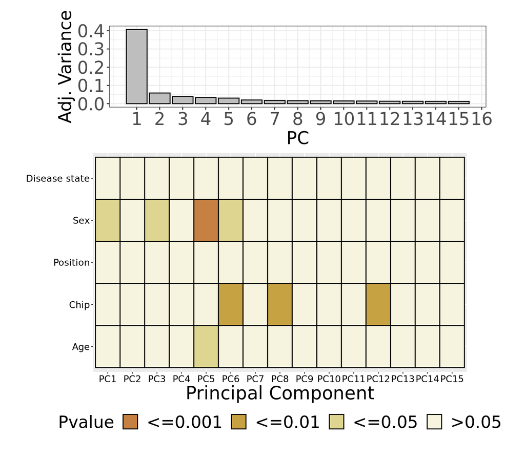

```r
#Run PCA.
source("~/KoborLab/kobor_space/kendrix/R_Functions/heat_scree_plot.R", local = knitr::knit_global())
heat_scree_plot(Loadings, Importance, Num, Order)
```

### Step 7: Save probe-filtered SWAN-normalised object.

```r
save(AMD_GenomicMSet.swan.filt, file = "~/KoborLab/kobor_space/kendrix/macular_degeneration/data/AMD_GenomicMSet.swan.filt.RData")
```

## Metadata Correlation

NOTE: Disease State may be slightly correlated with Row and Age may be slightly correlated with Chip.

```r
#Load AMD_GenomicMSet object and get pData.
load("~/KoborLab/kobor_space/kendrix/macular_degeneration/data/AMD_GenomicMSet.swan.filt.RData")
AMD_pData <- as.data.frame(pData(AMD_GenomicMSet.swan.filt))

#Subset the biological and technical variables to check correlation.
meta.cor <- AMD_pData[, c(2:4, 6:7)] #I didn't include tissue because they are all the same tissue.
colnames(meta.cor)[1] <- "Disease_State"
colnames(meta.cor)[4] <- "Row"
colnames(meta.cor)[5] <- "Chip"

#Turn categorical variables into numerical variables.
meta.cor$Disease_State <- as.numeric(unlist(as.factor(meta.cor$Disease_State)))
meta.cor$Sex <- as.numeric((unlist(as.factor(meta.cor$Sex))))
meta.cor$Age <- as.numeric(meta.cor$Age)
meta.cor$Row <- as.numeric(unlist(as.factor(meta.cor$Row)))
meta.cor$Chip <- as.numeric(unlist(as.factor(meta.cor$Chip)))

str(meta.cor)
```

```
## 'data.frame':    44 obs. of  5 variables:
##  $ Disease_State: num  2 2 2 1 1 1 2 1 1 1 ...
##  $ Sex          : num  2 2 2 2 2 1 2 2 1 2 ...
##  $ Age          : num  61 74 70 76 79 89 66 70 83 76 ...
##  $ Row          : num  3 10 12 1 3 5 7 9 11 2 ...
##  $ Chip         : num  2 2 2 4 4 4 4 4 4 4 ...
```

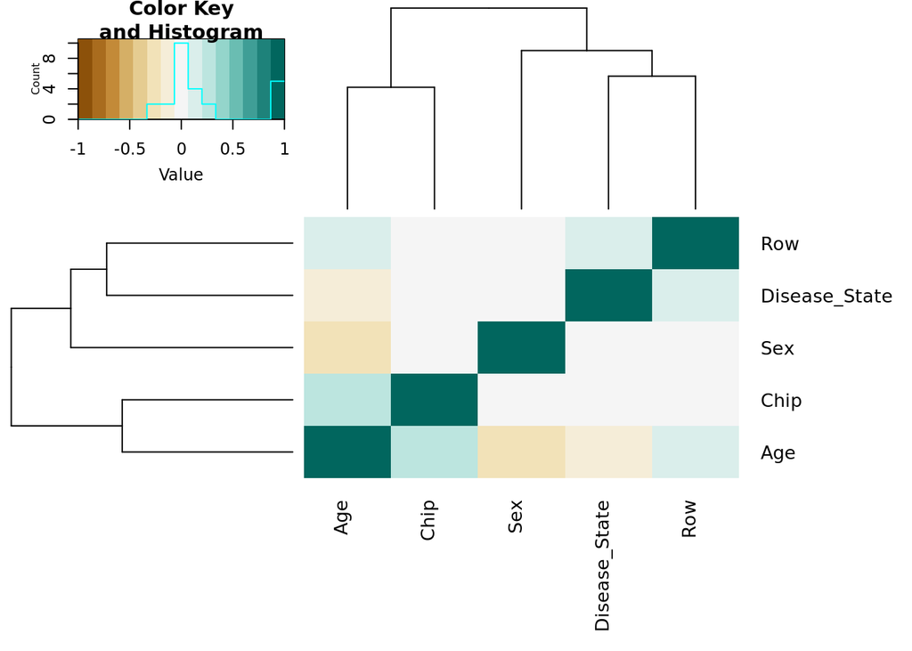

```r
#Metadata correlation.
grey <- colorRampPalette(brewer.pal(n = 9, "BrBG"))
heatmap.2(cor(meta.cor, use = "pairwise.complete.obs", method = "spearman"), cexCol = 1.0, cexRow = 1.0, col = grey, dendrogram = "both", scale = "none", margins = c(8,8), trace = "none", keysize = 2)
```

```r
#Correlation statistical test.
#Test between Age and Chip (in this case, Slide = Chip).
summary(lm(Age~Slide, data = AMD_pData))
```

```
##
## Call:
## lm(formula = Age ~ Slide, data = AMD_pData)
##
## Residuals:
##      Min       1Q   Median       3Q      Max
## -20.0000  -4.5000   0.4545   5.6591  14.0000
##
## Coefficients:
##                   Estimate Std. Error t value Pr(>|t|)
## (Intercept)         70.000      2.334  29.997   <2e-16 ***
## Slide200723300089    2.545      3.300   0.771   0.4451
## Slide200723300090    6.455      3.300   1.956   0.0575 .
## Slide200770460039    5.636      3.300   1.708   0.0954 .
## ---
## Signif. codes:  0 '***' 0.001 '**' 0.01 '*' 0.05 '.' 0.1 ' ' 1
##
## Residual standard error: 7.74 on 40 degrees of freedom
## Multiple R-squared:  0.1079, Adjusted R-squared:  0.04102
## F-statistic: 1.613 on 3 and 40 DF,  p-value: 0.2015
```

```r
summary(aov(Age~Slide, data = AMD_pData))
```

```
##             Df Sum Sq Mean Sq F value Pr(>F)
## Slide        3  289.9   96.63   1.613  0.201
## Residuals   40 2396.0   59.90
```

## EWAS

### Step 1: Load objects and clean up.

```r
#Load AMD_GenomicMSet object and get M-values and pData.
load("~/KoborLab/kobor_space/kendrix/macular_degeneration/data/AMD_GenomicMSet.swan.filt.RData")
AMD_pData <- as.data.frame(pData(AMD_GenomicMSet.swan.filt))
M_values.swan <- getM(AMD_GenomicMSet.swan.filt)
colnames(AMD_pData)[2] <- "Disease_State"
colnames(AMD_pData)[6] <- "Row"
colnames(AMD_pData)[7] <- "Chip"

AMD_pData$Disease_State <- as.factor(AMD_pData$Disease_State)
AMD_pData$Sex <- as.factor(AMD_pData$Sex)
AMD_pData$Row <- as.factor(AMD_pData$Row)
AMD_pData$Chip <- as.factor(AMD_pData$Chip)

#Check order.
identical(rownames(AMD_pData), colnames(M_values.swan)) #TRUE.
```

```
## [1] TRUE
```

```r
#Sanity check - there should be no NAs or infinite numbers - which could be a result of logit transformation of 0 or 1 beta values.
all(complete.cases(M_values.swan)) == "TRUE" #TRUE - meaning no NA or infinite numbers.
```

```
## [1] TRUE
```